```python
import numpy as np
import pandas as pd
```

# 1. 데이터 전처리

## 1.1 데이터 불러오기

```python
mydata = pd.read_csv("/Users/jaehyun/Downloads/주제분석 1주차/data.csv") # 맥북이라 경로가 살짝 다름
```

## 1.2 데이터 확인

```python
mydata.head() # 앞의 5개행을 보여줌
```

|  | transaction_id | apartment_id | city | dong | jibun | apt | addr_kr | exclusive_use_area | year_of_completion | transaction_year_month | transaction_date | floor | transaction_real_price |
| --- | --- | --- | --- | --- | --- | --- | --- | --- | --- | --- | --- | --- | --- |
| 0 | 0 | 7622 | 서울특별시 | 신교동 | 6-13 | 신현(101동) | 신교동 6-13 신현(101동) | 84.82 | 2002 | 200801 | 21~31 | 2 | 37500 |
| 1 | 1 | 5399 | 서울특별시 | 필운동 | 142 | 사직파크맨션 | 필운동 142 사직파크맨션 | 99.17 | 1973 | 200801 | 1~10 | 6 | 20000 |
| 2 | 2 | 3578 | 서울특별시 | 필운동 | 174-1 | 두레엘리시안 | 필운동 174-1 두레엘리시안 | 84.74 | 2007 | 200801 | 1~10 | 6 | 38500 |
| 3 | 3 | 10957 | 서울특별시 | 내수동 | 95 | 파크팰리스 | 내수동 95 파크팰리스 | 146.39 | 2003 | 200801 | 11~20 | 15 | 118000 |
| 4 | 4 | 10639 | 서울특별시 | 내수동 | 110-15 | 킹스매너 | 내수동 110-15 킹스매너 | 194.43 | 2004 | 200801 | 21~31 | 3 | 120000 |

```python
mydata.info() # 1216553개의 row, 13개의 column이 있음
```

```
<class 'pandas.core.frame.DataFrame'>
RangeIndex: 1216553 entries, 0 to 1216552
Data columns (total 13 columns):
 #   Column                  Non-Null Count    Dtype
---  ------                  --------------    -----
 0   transaction_id          1216553 non-null  int64
 1   apartment_id            1216553 non-null  int64
 2   city                    1216553 non-null  object
 3   dong                    1216553 non-null  object
 4   jibun                   1216553 non-null  object
 5   apt                     1216553 non-null  object
 6   addr_kr                 1216553 non-null  object
 7   exclusive_use_area      1216553 non-null  float64
 8   year_of_completion      1216553 non-null  int64
 9   transaction_year_month  1216553 non-null  int64
 10  transaction_date        1216553 non-null  object
 11  floor                   1216553 non-null  int64
 12  transaction_real_price  1216553 non-null  int64
dtypes: float64(1), int64(6), object(6)
memory usage: 120.7+ MB
```

```python
pd.isnull(mydata).sum() # 결측치가 없음을 확인할 수 있음
```

```
transaction_id            0
apartment_id              0
city                      0
dong                      0
jibun                     0
apt                       0
addr_kr                   0
exclusive_use_area        0
year_of_completion        0
transaction_year_month    0
transaction_date          0
floor                     0
transaction_real_price    0
dtype: int64
```

## 1.3 불필요한 행 삭제

```python
mydata = mydata.loc[mydata['city'] == '서울특별시'] # 서울만 추출
mydata.reset_index(drop = True, inplace = True) # drop = True로 인덱스 열로 추가되는거 방지
mydata.tail() # 잘 되었는지 확인
```

|  | transaction_id | apartment_id | city | dong | jibun | apt | addr_kr | exclusive_use_area | year_of_completion | transaction_year_month | transaction_date | floor | transaction_real_price |
| --- | --- | --- | --- | --- | --- | --- | --- | --- | --- | --- | --- | --- | --- |
| 742280 | 1196844 | 996 | 서울특별시 | 강일동 | 717 | 고덕리엔파크2단지 | 강일동 717 고덕리엔파크2단지 | 59.72 | 2011 | 201711 | 11~20 | 9 | 53000 |
| 742281 | 1196846 | 682 | 서울특별시 | 강일동 | 674 | 강일리버파크3단지 | 강일동 674 강일리버파크3단지 | 59.87 | 2009 | 201711 | 21~30 | 12 | 53000 |
| 742282 | 1196847 | 682 | 서울특별시 | 강일동 | 674 | 강일리버파크3단지 | 강일동 674 강일리버파크3단지 | 84.74 | 2009 | 201711 | 21~30 | 3 | 56500 |
| 742283 | 1196848 | 680 | 서울특별시 | 강일동 | 665 | 강일리버파크1단지 | 강일동 665 강일리버파크1단지 | 84.74 | 2009 | 201711 | 21~30 | 9 | 55500 |
| 742284 | 1196849 | 996 | 서울특별시 | 강일동 | 717 | 고덕리엔파크2단지 | 강일동 717 고덕리엔파크2단지 | 84.98 | 2011 | 201711 | 21~30 | 8 | 63750 |

## 1.4 변수 이름 바꾸기

```python
mydata = mydata.rename({'transaction_real_price' : 'price'},axis = 1) # rename 함수 이용
```

## 1.5 불필요한 변수 삭제

```python
drop_list = ['transaction_id','apartment_id','jibun','city'] # 삭제할 열을 list로
mydata = mydata.drop(drop_list,axis = 1) # 한 번에 삭제
```

## 1.6 연/월 뽑기

```python
mydata['transaction_month'] = mydata['transaction_year_month'].apply(lambda x : str(x)[4:6])
mydata['transaction_year'] = mydata['transaction_year_month'].apply(lambda x : x//100)

# year와 month 모두 int형으로 하는지 string형으로 하는지 명시되어 있지 않아서 일단 year는 기존 데이터가 int형이어서 int로 놓고, month는 3번문제에서 str형으로 해야 하므로 str로 놓겠습니다.

mydata.head()
```

|  | dong | apt | addr_kr | exclusive_use_area | year_of_completion | transaction_year_month | transaction_date | floor | price | transaction_month | transaction_year |
| --- | --- | --- | --- | --- | --- | --- | --- | --- | --- | --- | --- |
| 0 | 신교동 | 신현(101동) | 신교동 6-13 신현(101동) | 84.82 | 2002 | 200801 | 21~31 | 2 | 37500 | 01 | 2008 |
| 1 | 필운동 | 사직파크맨션 | 필운동 142 사직파크맨션 | 99.17 | 1973 | 200801 | 1~10 | 6 | 20000 | 01 | 2008 |
| 2 | 필운동 | 두레엘리시안 | 필운동 174-1 두레엘리시안 | 84.74 | 2007 | 200801 | 1~10 | 6 | 38500 | 01 | 2008 |
| 3 | 내수동 | 파크팰리스 | 내수동 95 파크팰리스 | 146.39 | 2003 | 200801 | 11~20 | 15 | 118000 | 01 | 2008 |
| 4 | 내수동 | 킹스매너 | 내수동 110-15 킹스매너 | 194.43 | 2004 | 200801 | 21~31 | 3 | 120000 | 01 | 2008 |

## 1.7 필요 연도 뽑기

```python
mydata = mydata.loc[mydata['transaction_year']>=2012] # 2012년도부터의 데이터만 추출
mydata = mydata.reset_index(drop = True)
```

```python
mydata.head()
```

|  | dong | apt | addr_kr | exclusive_use_area | year_of_completion | transaction_year_month | transaction_date | floor | price | transaction_month | transaction_year |
| --- | --- | --- | --- | --- | --- | --- | --- | --- | --- | --- | --- |
| 0 | 사직동 | 광화문풍림스페이스본(9-0) | 사직동 9 광화문풍림스페이스본(9-0) | 95.88 | 2008 | 201201 | 1~10 | 6 | 70000 | 01 | 2012 |
| 1 | 사직동 | 광화문풍림스페이스본(9-0) | 사직동 9 광화문풍림스페이스본(9-0) | 108.55 | 2008 | 201201 | 11~20 | 11 | 100500 | 01 | 2012 |
| 2 | 사직동 | 광화문풍림스페이스본(9-0) | 사직동 9 광화문풍림스페이스본(9-0) | 94.51 | 2008 | 201201 | 11~20 | 1 | 65800 | 01 | 2012 |
| 3 | 수송동 | 로얄팰리스스위트 | 수송동 85 로얄팰리스스위트 | 42.87 | 2005 | 201201 | 1~10 | 8 | 30500 | 01 | 2012 |
| 4 | 수송동 | 로얄팰리스스위트 | 수송동 85 로얄팰리스스위트 | 39.67 | 2005 | 201201 | 21~31 | 15 | 30500 | 01 | 2012 |

# 2. 데이터 시각화

```python
import matplotlib.pyplot as plt
import seaborn as sns
plt.rcParams['font.family'] = 'AppleGothic' # seaborn에서 한글 폰트 깨짐 방지
```

## 2.1 거래가격 분포 확인

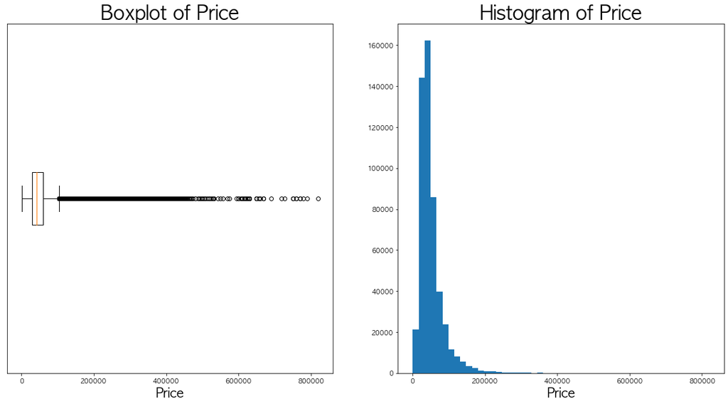

```python
firstplot = plt.figure(figsize=(20,10)) # (20, 10)  사이즈의 firstplot이란 plot을 생성할거임
axes1 = firstplot.add_subplot(1, 2, 1) # 플랏을 분할할건데, 1행 2열로 분할할거고, 이건 그중 첫번째 플랏임
axes2 = firstplot.add_subplot(1, 2, 2) # 이건 그중에 두번째 플랏임

axes1.boxplot(mydata['price'],vert = False) # 첫번째 플랏에는 boxplot을 그릴건데, 가로로 눕힐거임
axes1.set_title("Boxplot of Price", fontsize = 30) # 플랏 제목도 달고, 폰트 사이즈도 지정줄거임
axes1.set_xlabel("Price", fontsize = 20)
axes1.get_yaxis().set_visible(False) # 왼쪽 1 숨김

axes2.hist(mydata['price'],50) #두번째 플랏은 히스토그램 그릴거임
axes2.set_title("Histogram of Price", fontsize = 30)
axes2.set_xlabel("Price", fontsize = 20)
```

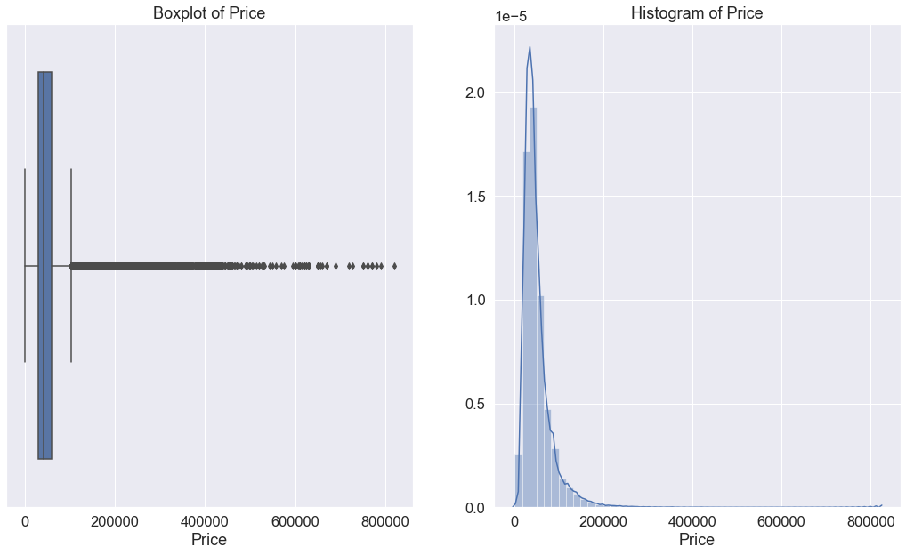

```python
sns.set(font_scale = 1.5 ) # 폰트사이즈를 전체적으로 키워준다
fig, axs = plt.subplots(ncols = 2, figsize = (18, 10)) #서브플랏을 1행 2열로 분할하고
sns.boxplot(ax = axs[0], data = mydata['price'], orient = 'h') #박스플랏
axs[0].set_title("Boxplot of Price") # 제목 설정
axs[0].set_xlabel("Price") # x축 이름 설정
axs[0].set(yticklabels= []) # 1 제거

sns.distplot(mydata['price'], bins = 50, hist = True)#히스토그램
axs[1].ticklabel_format(axis = 'y', style = 'sci',scilimits = (-5,-5)) # scientific notation
axs[1].set_title("Histogram of Price")
axs[1].set_xlabel("Price")
```

<해석>

## 2.2 거래연도 분포 확인/ 거래 연도별 가격 분포 확인

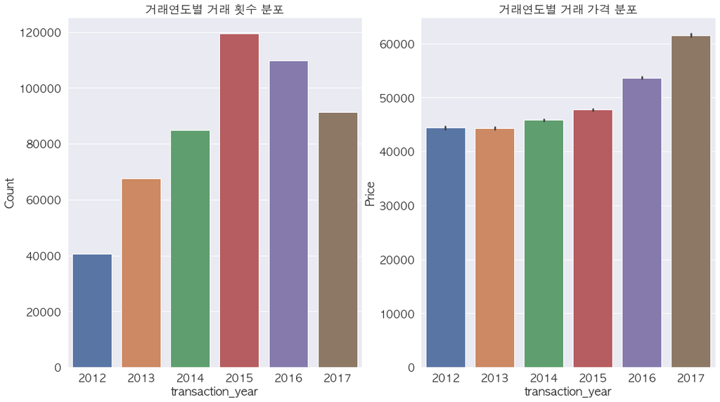

```python
plt.rcParams['font.family'] = 'AppleGothic'
fig, axs = plt.subplots(ncols = 2, figsize = (18, 10))

sns.countplot(ax = axs[0], data = mydata, x = 'transaction_year') # 거래연도별 거래 횟수 분포
axs[0].set_title("거래연도별 거래 횟수 분포") # 제목 설정
axs[0].set_ylabel("Count") # y축 이름 설정 : 안해놓으면 소문자로 나오길래 그냥 해놨습니다.

sns.barplot(ax = axs[1], data = mydata, x = 'transaction_year', y = 'price') # 거래연도별 거래 횟수 분포
axs[1].set_title("거래연도별 거래 가격 분포") # 제목 설정
axs[1].set_ylabel("Price") # y축 이름 설정
```

<해석>

(1) 거래 횟수 : 2015년이 가장 많고, 2016, 2017, 2014, 2013, 2012 순으로 뒤를 이음. 점점 증가해서 2015년에 피크를 찍고 다시 점점 내려오는 추세이다.

(2) 거래 가격 분포 : 점점 증가하는 추세이며, 특히 가격의 상승폭이 점점 커지는 듯 하다.

## 2.3 층 분포 확인 / 층별 가격 분포 확인

```
[[]]
```

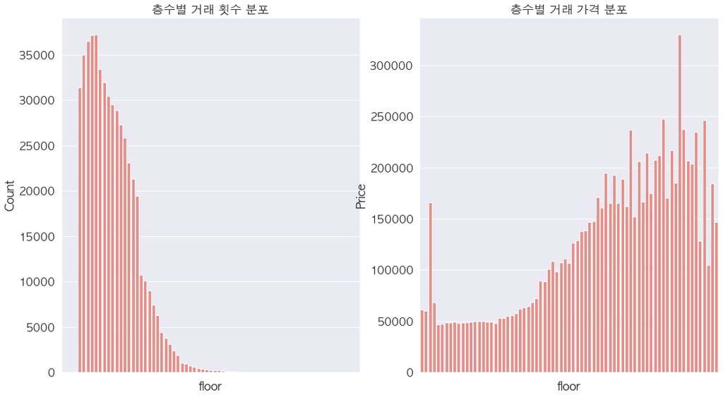

```python
fig, axs = plt.subplots(ncols = 2, figsize = (18, 10))

sns.countplot(ax= axs[0], data = mydata, x = 'floor', color = '#FC7F77')
#sns.barplot(ax = axs[0], x = floor_count.index, y = floor_count['price'], color = "#FC7F77") # 거래연도별 거래 횟수 분포
axs[0].set_title("층수별 거래 횟수 분포") # 제목 설정
axs[0].set_ylabel("Count") # y축 이름 설정
axs[0].set(xticklabels= []) # x축 제거

sns.barplot(ax = axs[1],data = mydata,x = 'floor', y ='price', color = "#FC7F77", ci = None) # 거래연도별 거래 횟수 분포, ci = None으로 에러바 숨김
axs[1].set_title("층수별 거래 가격 분포") # 제목 설정
axs[1].set_ylabel("Price") # y축 이름 설정
axs[1].set(xticklabels = []) # x축 제거
```

<해석>

(1) 저층의 아파트의 거래량이 훨씬 높은 편이다.

(2) 층수와 가격이 완벽하게 정비례 관계를 이루지는 않지만, 확실히 저층부의 가격보다 고층부의 가격이 높은 편을 형성한다는 것을 볼 수 있다.

## 2.4 완공연도 분포 확인 / 완공 연도별 가격 분포 확인

```
[[]]
```

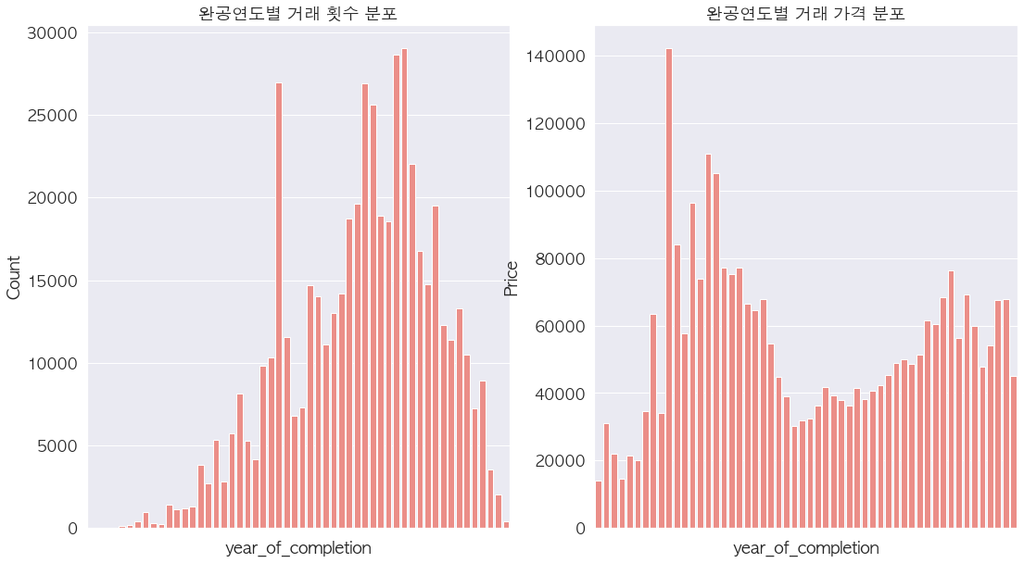

```python
fig, axs = plt.subplots(ncols = 2, figsize = (18, 10))

sns.countplot(ax = axs[0], data = mydata, x = 'year_of_completion', color = "#FC7F77") # 거래연도별 거래 횟수 분포
axs[0].set_title("완공연도별 거래 횟수 분포") # 제목 설정
axs[0].set_ylabel("Count") # y축 이름 설정
axs[0].set(xticklabels= []) # x축 제거

sns.barplot(ax = axs[1], data = mydata, x = 'year_of_completion', y = 'price', color = "#FC7F77", ci = None) # 거래연도별 거래 횟수 분포, 패키지 과제에 여기도 error bar 없길래 일단 없앨게요(?)
axs[1].set_title("완공연도별 거래 가격 분포") # 제목 설정
axs[1].set_ylabel("Price") # y축 이름 설정
axs[1].set(xticklabels = []) # x축 제거
```

<해석>

(1) 거래량은 대체로 증가하다 감소하는 추세이므로(중간에 특이하게 확 올라간 지점 제외 - 저 때 어떤 이슈가 있었던 것으로 추정) 완공연도가 최근일수록 거래량이 증가한다고 확정적으로 얘기할 수 없다. 하지만, 완공 연도가 최근일수록 이루어질 수 있는 거래량 자체가 과거에 지어진 아파트들에 비해 적은게 당연하므로 단정적으로 아니다 라고 얘기할 수도 없다고 생각한다.

(2) 최근의 아파트들이 더 비싸다고 말할 수 없다. 오히려 과거에 지어진 아파트가 조금 대체적으로 높은 경향성마저 보인다.

# 3. 파생변수 생성

## 3.1 아파트 연차 변수 생성

```python
mydata['until_trans'] = mydata['transaction_year'] - mydata['year_of_completion'] + 1 # 연차 = 거래연도 - 완공연도 + 1
```

```
[[]]
```

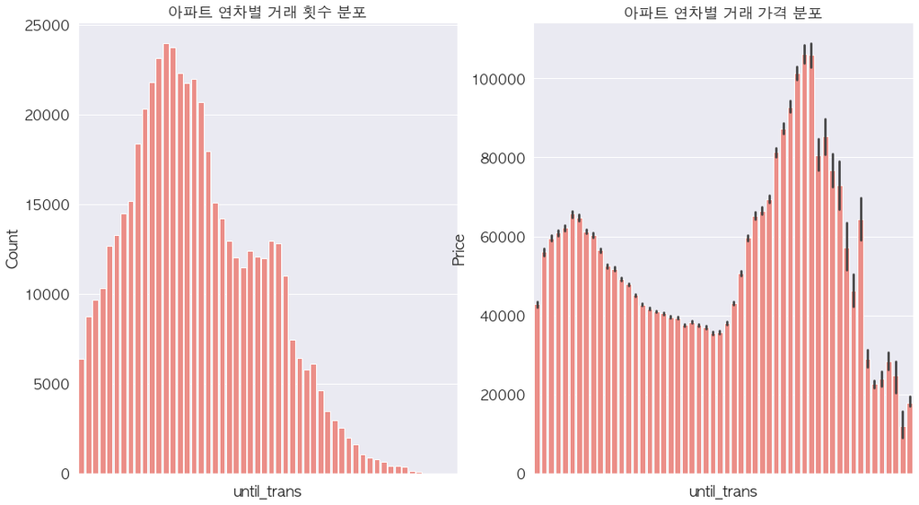

```python
fig, axs = plt.subplots(ncols = 2, figsize = (18, 10))

sns.countplot(ax = axs[0], data = mydata, x = 'until_trans', color = "#FC7F77") # 거래연도별 거래 횟수 분포
axs[0].set_title("아파트 연차별 거래 횟수 분포") # 제목 설정
axs[0].set_ylabel("Count") # y축 이름 설정
axs[0].set(xticklabels= []) # x축 제거

sns.barplot(ax = axs[1],data = mydata, x='until_trans', y ='price', color = "#FC7F77") # 거래연도별 거래 횟수 분포
axs[1].set_title("아파트 연차별 거래 가격 분포") # 제목 설정
axs[1].set_ylabel("Price") # y축 이름 설정
axs[1].set(xticklabels = []) # x축 제거
```

<해석>

(1) 연차에 따라서 거래량이 증가하다가 정점을 찍고 감소하는 모양을 보인다. 연차가 오래된 아파트는 거래량이 매우 적은 것을 확인할 수 있다.

(2) 연차가 오래됐다고 해서 가격이 줄어들지는 않는다. 오히려 연차가 매우 오래된 아파트를 제외하면 연차가 적은 아파트보다 연차가 오래된 아파트가 대체로 비싼 가격을 형성한 것을 볼 수 있다.

## 3-2 거래 일 변수 변환

```python
mydata['transaction_date'] = np.where(mydata['transaction_date'] == '1~10',0,
                                      np.where(mydata['transaction_date'] == '11~20',1,2))
```

## 3-3 월 변수와 10일 단위 변수 통합

```python
mydata['transaction_month_date'] = 3*mydata['transaction_month'].apply(lambda x : int(x)) + mydata['transaction_date']

mydata[['transaction_month_date','transaction_month','transaction_date']]
```

|  | transaction_month_date | transaction_month | transaction_date |
| --- | --- | --- | --- |
| 0 | 3 | 01 | 0 |
| 1 | 4 | 01 | 1 |
| 2 | 4 | 01 | 1 |
| 3 | 3 | 01 | 0 |
| 4 | 5 | 01 | 2 |
| ... | ... | ... | ... |
| 513523 | 34 | 11 | 1 |
| 513524 | 35 | 11 | 2 |
| 513525 | 35 | 11 | 2 |
| 513526 | 35 | 11 | 2 |
| 513527 | 35 | 11 | 2 |

513528 rows × 3 columns

```python
import math
```

```python
mydata['sin_date'] = np.sin((math.pi/2)*mydata.transaction_month_date) # sin, cos 파생 변수 생성
mydata['cos_date'] = np.cos((math.pi/2)*mydata.transaction_month_date)
```

```python
drop_list = ['year_of_completion','transaction_year_month',
             'transaction_date','transaction_month','transaction_month_date'] # 1번과 비슷하게 리스트 설정
mydata = mydata.drop(drop_list,axis=1) # 한번에 drop
mydata.head()
```

|  | dong | apt | addr_kr | exclusive_use_area | floor | price | transaction_year | until_trans | sin_date | cos_date |
| --- | --- | --- | --- | --- | --- | --- | --- | --- | --- | --- |
| 0 | 사직동 | 광화문풍림스페이스본(9-0) | 사직동 9 광화문풍림스페이스본(9-0) | 95.88 | 6 | 70000 | 2012 | 5 | -1.000000e+00 | -1.836970e-16 |
| 1 | 사직동 | 광화문풍림스페이스본(9-0) | 사직동 9 광화문풍림스페이스본(9-0) | 108.55 | 11 | 100500 | 2012 | 5 | -2.449294e-16 | 1.000000e+00 |
| 2 | 사직동 | 광화문풍림스페이스본(9-0) | 사직동 9 광화문풍림스페이스본(9-0) | 94.51 | 1 | 65800 | 2012 | 5 | -2.449294e-16 | 1.000000e+00 |
| 3 | 수송동 | 로얄팰리스스위트 | 수송동 85 로얄팰리스스위트 | 42.87 | 8 | 30500 | 2012 | 8 | -1.000000e+00 | -1.836970e-16 |
| 4 | 수송동 | 로얄팰리스스위트 | 수송동 85 로얄팰리스스위트 | 39.67 | 15 | 30500 | 2012 | 8 | 1.000000e+00 | 3.061617e-16 |

## 3.5 삼각변환을 통한 장점

삼각변환을 사용하면 시간의 연속성과 주기성을 나타내는데 큰 효과를 가져올 수 있다.

# 4. 텍스트 데이터 다루기

## 4.1 아파트 이름 한글부분만 뽑기

```python
def getText(text) :  # 가독성을 위해 함수 생성
    dummy_val = ['1','2','3','4','5','6','7','8','9','0','-','(',')'] # 나오는 특수문자들과 숫자들을 확인해본 결과 다음과 같은 문자가 있을 경우 제외
    result = ''
    for letter in text :
        if letter in dummy_val : # 숫자와 특수문자가 있으면 제외하고
            continue
        else :
            result += letter # 문자만 있으면 추가
    return result
```

```python
apt = mydata['apt'].apply(lambda x : getText(x))
apt.head(10)
```

```
0    광화문풍림스페이스본
1    광화문풍림스페이스본
2    광화문풍림스페이스본
3      로얄팰리스스위트
4      로얄팰리스스위트
5      로얄팰리스스위트
6      로얄팰리스스위트
7        현대뜨레비앙
8        현대뜨레비앙
9        현대뜨레비앙
Name: apt, dtype: object
```

## 4.2 아파트 이름 DTM

```python
from sklearn.feature_extraction.text import CountVectorizer
```

```python
apt_array = np.array(apt) # np.array로 타입 변경
count_vec = CountVectorizer(min_df = 5) # 객체 생성
dtm = count_vec.fit_transform(apt_array) # dtm 생성
count_vec.vocabulary_ # 각 단어 등장 횟수 출력
```

```
{'광화문풍림스페이스본': 365,
 '로얄팰리스스위트': 1134,
 '현대뜨레비앙': 3909,
 '운현신화타워': 2841,
 '창신쌍용': 3296,
 '동대문': 865,
 '두산': 986,
 '종로청계힐스테이트': 3178,
 '동일상가': 956,
 '렉스팰리스': 1119,
 '삼성': 1725,
 '대아파크빌': 722,
 '세종로대우': 2136,
 '파크팰리스': 3576,
 '킹스매너': 3474,
 '경희궁의아침단지': 272,
 '동성아파트동': 902,
 '아남': 2471,
 '동아': 913,
 '롯데캐슬': 1152,
 '로잔': 1137,
 '크래스빌': 3465,
 '롯데낙천대': 1148,
 '인왕산아이파크': 3023,
 '현대': 3893,
 '미도파': 1385,
 '효성쥬얼리시티': 4062,
 '종로센트레빌': 3174,
 '대성맨션': 709,
 '청운현대': 3399,
 'cs타워': 12,
 '렉스빌': 1118,
 '창신이수': 3297,
 '브라운스톤창신': 1650,
 '벽산블루밍평창힐스': 1558,
 '갑을': 117,
 'mid그린동': 53,
 '르트랑시망': 1185,
 '무악다온채': 1350,
 '세종': 2133,
```

[output cut: 946 more lines]

```
 '송천센트레빌': 2163,
 '래미안트리베라단지': 1097,
 '벽산라이브파크': 1551,
 '미아한일유앤아이': 1411,
 '미아차래미안': 1410,
 '삼각산아이원': 1701,
 '현대성우': 3928,
 '요진': 2745,
 '한진그랑빌해모로': 3836,
 '효성인텔리안': 4061,
 '한솔솔파크': 3767,
 '주공단지': 3186,
 '기산그린': 470,
 '번동솔그린': 1531,
 ...}
```

```python
dtm.toarray() # 문서단어행렬 : 개수가 워낙 많아 0이 많이 보이지만 뜯어보면 0과 1이 아닌 값을 확인할 수 있었음
```

```
array([[0, 0, 0, ..., 0, 0, 0],
       [0, 0, 0, ..., 0, 0, 0],
       [0, 0, 0, ..., 0, 0, 0],
       ...,
       [0, 0, 0, ..., 0, 0, 0],
       [0, 0, 0, ..., 0, 0, 0],
       [0, 0, 0, ..., 0, 0, 0]])
```

## 4.3 아파트 이름 tf-idf

```python
from sklearn.feature_extraction.text import TfidfVectorizer
```

```python
tf_idf_vec = TfidfVectorizer(min_df = 5) # 객체 생성
tf_idf = tf_idf_vec.fit_transform(apt_array).toarray()
tf_idf_vec.vocabulary_ # 각 단어 등장 횟수 출력
```

```
{'광화문풍림스페이스본': 365,
 '로얄팰리스스위트': 1134,
 '현대뜨레비앙': 3909,
 '운현신화타워': 2841,
 '창신쌍용': 3296,
 '동대문': 865,
 '두산': 986,
 '종로청계힐스테이트': 3178,
 '동일상가': 956,
 '렉스팰리스': 1119,
 '삼성': 1725,
 '대아파크빌': 722,
 '세종로대우': 2136,
 '파크팰리스': 3576,
 '킹스매너': 3474,
 '경희궁의아침단지': 272,
 '동성아파트동': 902,
 '아남': 2471,
 '동아': 913,
 '롯데캐슬': 1152,
 '로잔': 1137,
 '크래스빌': 3465,
 '롯데낙천대': 1148,
 '인왕산아이파크': 3023,
 '현대': 3893,
 '미도파': 1385,
 '효성쥬얼리시티': 4062,
 '종로센트레빌': 3174,
 '대성맨션': 709,
 '청운현대': 3399,
 'cs타워': 12,
 '렉스빌': 1118,
 '창신이수': 3297,
 '브라운스톤창신': 1650,
 '벽산블루밍평창힐스': 1558,
 '갑을': 117,
 'mid그린동': 53,
 '르트랑시망': 1185,
 '무악다온채': 1350,
 '세종': 2133,
```

[output cut: 946 more lines]

```
 '송천센트레빌': 2163,
 '래미안트리베라단지': 1097,
 '벽산라이브파크': 1551,
 '미아한일유앤아이': 1411,
 '미아차래미안': 1410,
 '삼각산아이원': 1701,
 '현대성우': 3928,
 '요진': 2745,
 '한진그랑빌해모로': 3836,
 '효성인텔리안': 4061,
 '한솔솔파크': 3767,
 '주공단지': 3186,
 '기산그린': 470,
 '번동솔그린': 1531,
 ...}
```

```python
tf_idf # 문서단어행렬
```

```
array([[0., 0., 0., ..., 0., 0., 0.],
       [0., 0., 0., ..., 0., 0., 0.],
       [0., 0., 0., ..., 0., 0., 0.],
       ...,
       [0., 0., 0., ..., 0., 0., 0.],
       [0., 0., 0., ..., 0., 0., 0.],
       [0., 0., 0., ..., 0., 0., 0.]])
```

## 4.4 질문

원래 데이터 프레임에 해당 행렬을 쓰게 된다면 애초에 이 행렬이 해당 데이터로부터 fit 시킨 행렬이기 때문에 해당 데이터에서만 적중률이 매우 높게 나올 수 밖에 없다. 즉, 해당 데이터에 과적합 된 모델링이 된다.

대안으로는 가져온 단어 set을 K-fold 방식 등을 이용해 trani set과 test set으로 나눠 교차 검증을 진행하거나, 아니면 미리 다른 train set을 구해와서 교차검증을 수행한다면 더 훌륭한 모델링이 될 수 있다.

## 4.5 질문

우선, 모델링을 해보지 않고 추측할 수 있는 것은 너무 데이터수가 많기 때문에, word2vec을 사용했을 때 수행하는데 걸리는 시간이 매우 길 것이라는 점입니다. 해당하는 데이터의 수*100 차원 만큼의 내적계산을 하는 데 온전히 감당할 수 있을지..

또한, word2vec의 강점 중 하나인 문맥적인 의미를 보존하는 임베딩에 아파트이름을 적용시킨다는 게 사실 시도해보지 않아 어떤 의미가 될 수 있을지 선뜻 떠오르지 않습니다.(다시말해, 저런 긴 수행시간을 들일만큼 의미있는 결과를 도출할까 라는 의문이 드는게 사실)

물론, 이 모든 것은 직접 수행하기 전까지는 단정하기 힘들 듯 합니다.(특히, 저는 word2vec을 심도있게 공부한 적이 없어서 이런 표면적인 이유와 추측밖에 못하겠습니다..)

# 5. 인코딩

```python
mydata = mydata.drop(columns = ['addr_kr'])
```

## 5.1 원핫 인코딩

```python
dong_onehot = pd.get_dummies(mydata['dong']) # get_dummies를 이용한 원핫인코딩
```

```python
dong_onehot.info()
```

```
<class 'pandas.core.frame.DataFrame'>
RangeIndex: 513528 entries, 0 to 513527
Columns: 329 entries, 가락동 to 흥인동
dtypes: uint8(329)
memory usage: 161.1 MB
```

```python
apt_onehot = pd.get_dummies(mydata['apt'])
```

```python
apt_onehot.info()
```

```
<class 'pandas.core.frame.DataFrame'>
RangeIndex: 513528 entries, 0 to 513527
Columns: 6765 entries, (1-10) to 힐하우스(802-3)
dtypes: uint8(6765)
memory usage: 3.2 GB
```

one-hot 인코딩은 단어의 개수만큼 컬럼이 생성된다. 따라서, 지금의 경우에는 단어가 매우 많기때문에 컬럼이 매우 많아져서 머신러닝 시 수행시간이 매우 오래걸릴 수 있으므로 적절하다고 생각되지 않는다.

## 5.2 레이블(label) 인코딩

```python
from sklearn.preprocessing import LabelEncoder # 사이킷 런 이용 에정
```

```python
label_encoder = LabelEncoder() # 객체 생성
label_encoder.fit(mydata['transaction_year']) # 객체에 fit
labels = label_encoder.transform(mydata['transaction_year']) # 객체에 transfrom
```

```python
mydata['transaction_year'] = labels
```

```python
mydata.head()
```

|  | dong | apt | exclusive_use_area | floor | price | transaction_year | until_trans | sin_date | cos_date |
| --- | --- | --- | --- | --- | --- | --- | --- | --- | --- |
| 0 | 사직동 | 광화문풍림스페이스본(9-0) | 95.88 | 6 | 70000 | 0 | 5 | -1.000000e+00 | -1.836970e-16 |
| 1 | 사직동 | 광화문풍림스페이스본(9-0) | 108.55 | 11 | 100500 | 0 | 5 | -2.449294e-16 | 1.000000e+00 |
| 2 | 사직동 | 광화문풍림스페이스본(9-0) | 94.51 | 1 | 65800 | 0 | 5 | -2.449294e-16 | 1.000000e+00 |
| 3 | 수송동 | 로얄팰리스스위트 | 42.87 | 8 | 30500 | 0 | 8 | -1.000000e+00 | -1.836970e-16 |
| 4 | 수송동 | 로얄팰리스스위트 | 39.67 | 15 | 30500 | 0 | 8 | 1.000000e+00 | 3.061617e-16 |

레이블 인코딩의 경우 문자를 숫자로 변환하면서 숫자의 크고작음이 반영 된다는 문제점이 있다. 하지만, 2.2의 시각화를 참고해서 얘기하자면 우리가 레이블 인코딩한 변수가 선형 회귀와 같은 ML 알고리즘 계열이 아니므로 적절한 인코딩이라고 생각된다.

## 5.3 레이블(label) 인코딩

```python
dong_label_encoder = LabelEncoder()
dong_label_encoder.fit(mydata['dong'])
dong_label = dong_label_encoder.transform(mydata['dong'])
```

```python
mydata['dong'] = dong_label # dataFrame에 저장
```

```python
apt_label_encoder = LabelEncoder()
apt_label_encoder.fit(mydata['apt'])
apt_label = apt_label_encoder.transform(mydata['apt'])
```

```python
mydata['apt'] = apt_label
```

```python
mydata.head()
```

|  | dong | apt | exclusive_use_area | floor | price | transaction_year | until_trans | sin_date | cos_date |
| --- | --- | --- | --- | --- | --- | --- | --- | --- | --- |
| 0 | 130 | 805 | 95.88 | 6 | 70000 | 0 | 5 | -1.000000e+00 | -1.836970e-16 |
| 1 | 130 | 805 | 108.55 | 11 | 100500 | 0 | 5 | -2.449294e-16 | 1.000000e+00 |
| 2 | 130 | 805 | 94.51 | 1 | 65800 | 0 | 5 | -2.449294e-16 | 1.000000e+00 |
| 3 | 164 | 2042 | 42.87 | 8 | 30500 | 0 | 8 | -1.000000e+00 | -1.836970e-16 |
| 4 | 164 | 2042 | 39.67 | 15 | 30500 | 0 | 8 | 1.000000e+00 | 3.061617e-16 |

레이블 인코딩은 위에서 언급했듯이 숫자의 크고 작음이 반영된다는 문제점을 가지고 있다. apt 및 dong과 다른 변수와의 관계를 고려할 때 이를 회귀 알고리즘에 적용할 것이라면 적절하지 않고, 트리 계열 알고리즘에 사용할 것이면 큰 문제가 없다.

## 5.4 mean encoding

```python
apt_mean = mydata.groupby('apt')['price'].mean() # target 변수인 price에 대한 apt에 따른 mean 값 도출
```

```python
mydata['apt'] = mydata['apt'].apply(lambda x : apt_mean[x]) # dataframe에 넣어줌
```

```python
mydata.head()
```

|  | dong | apt | exclusive_use_area | floor | price | transaction_year | until_trans | sin_date | cos_date |
| --- | --- | --- | --- | --- | --- | --- | --- | --- | --- |
| 0 | 130 | 91174.766355 | 95.88 | 6 | 70000 | 0 | 5 | -1.000000e+00 | -1.836970e-16 |
| 1 | 130 | 91174.766355 | 108.55 | 11 | 100500 | 0 | 5 | -2.449294e-16 | 1.000000e+00 |
| 2 | 130 | 91174.766355 | 94.51 | 1 | 65800 | 0 | 5 | -2.449294e-16 | 1.000000e+00 |
| 3 | 164 | 36609.649123 | 42.87 | 8 | 30500 | 0 | 8 | -1.000000e+00 | -1.836970e-16 |
| 4 | 164 | 36609.649123 | 39.67 | 15 | 30500 | 0 | 8 | 1.000000e+00 | 3.061617e-16 |

mean encoding의 경우 단순히 구분이 아니라 내가 인코딩하려는 feature와 예측하려고하는 target(여기서는 'price') 변수 간의 어떤 수치적인 관계를 범주형 변수에서도 찾으려는 인코딩인데, 이 예제에서는 각 apt값에 따른 price의 평균을 사용하여 apt를 수치적으로 표현하면서도 구분하려는 시도이다.

이렇게 될 경우, 회귀나 분류 알고리즘 모두에서 편차가 작은 편인 장점이 있지만, 오버피팅의 문제가 생길 수 있다. 즉, 하나의 label 값의 대표값을 하나의 mean으로만 사용하는데, 이 과정에서 overfitting이 생길 수 있다. 물론, trian set을 구해서 예측력을 높이는 시도를 할 수 있는 등의 방법이 존재한다.

적절성의 여부는 현 단계에서는 모델링을 진행하지 않고 인코딩만 한 것이라 판단하기 힘들 듯 하지만, 위에서 언급한 mean encoding의 장점을 참고하면 레이블 인코딩보다는 적절하리라 생각된다.